# Activity Monitoring - Reproducible Research

Siddharth Gusain

October 1, 2020

## Loading and preprocessing the data

We will start by downloading the data from [Activity monitoring data](https://d396qusza40orc.cloudfront.net/repdata%2Fdata%2Factivity.zip), the data was downloaded at 2020-10-02.

Methodology for downloading and preprocessing is given below.

```r
download.file("https://d396qusza40orc.cloudfront.net/repdata%2Fdata%2Factivity.zip",destfile = "activity.zip")
data <- read.csv(unz("activity.zip","activity.csv"),stringsAsFactors = FALSE)
library(lubridate)
library(dplyr)
library(ggplot2)
data$date<-ymd(data$date)
```

## Total number of steps

The summary of sum, mean and median of steps per day is given below.

```r
steps_summary_date <- data %>% group_by(date) %>% summarise(steps = sum (steps))
sumsteps <- sum(steps_summary_date$steps,na.rm = T)
meansteps <- as.integer(mean(steps_summary_date$steps,na.rm = T))
mediansteps <- median(steps_summary_date$steps,na.rm = T)
```

As calculated in the code chunk above, the sum is **570608**, the mean is **10766** and the median is **10765**.

Furthermore, a histogram of the total number of steps per day is given below:

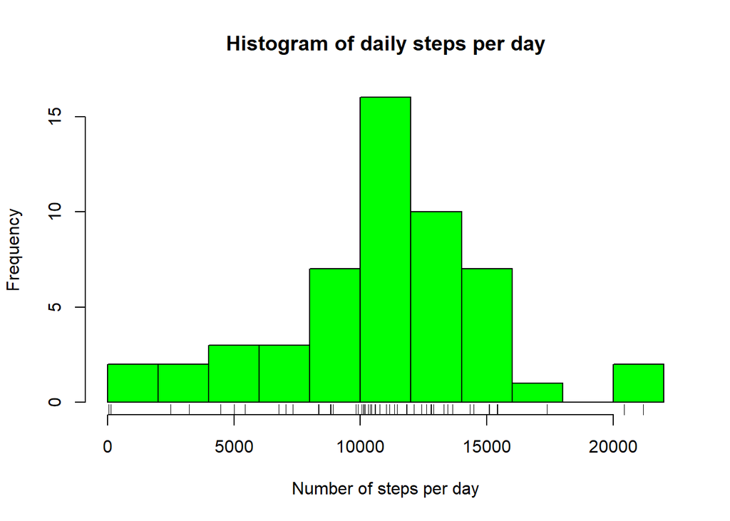

```r
plotdata <- data %>% group_by(date) %>% summarise(steps = sum(steps))
hist(plotdata$steps, breaks = 15, xlab = "Number of steps per day", main = "Histogram of daily steps per day", col = "green")
rug(plotdata$steps)
```

## Average daily activity pattern

A time series plot of 5-minute intervals against average number of steps taken across those intervals is given below.

```r
activitypatterndata <- data %>% select(steps,interval) %>% group_by(interval) %>% summarise(steps=mean(steps,na.rm = T))
```

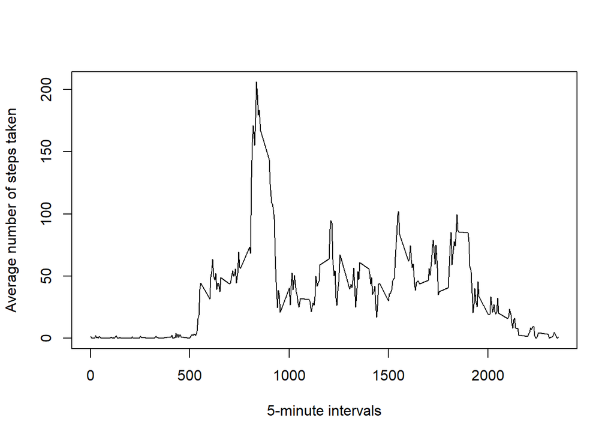

```r
plot(activitypatterndata$interval,activitypatterndata$steps,type="l",xlab = "5-minute intervals", ylab = "Average number of steps taken")
```

The details of interval wtih maximum number of average steps is given below.

```r
activitypatterndata[which.max(activitypatterndata$steps),]
```

```
## # A tibble: 1 x 2
##   interval steps
##      <int> <dbl>
## 1      835  206.
```

## Imputing missing values

Using the sum function to calculate the total number of missing values in the "steps" variable as "date" and "interval"" have no missing values.

```r
sumna <- sum(is.na(data$steps))
```

The total missing values in the steps variable of the dataset are **2304**.

I will now replace the "NA" values with the mean value of that particular interval's remaining values.

```r
replacewithmean <- function(x){replace(x, is.na(x), mean(x, na.rm = TRUE))}
completedata <- data %>% group_by(interval) %>% mutate( steps = replacewithmean(steps))
```

The total number of steps taken each day as per the dataset without missing values can be seen as below:

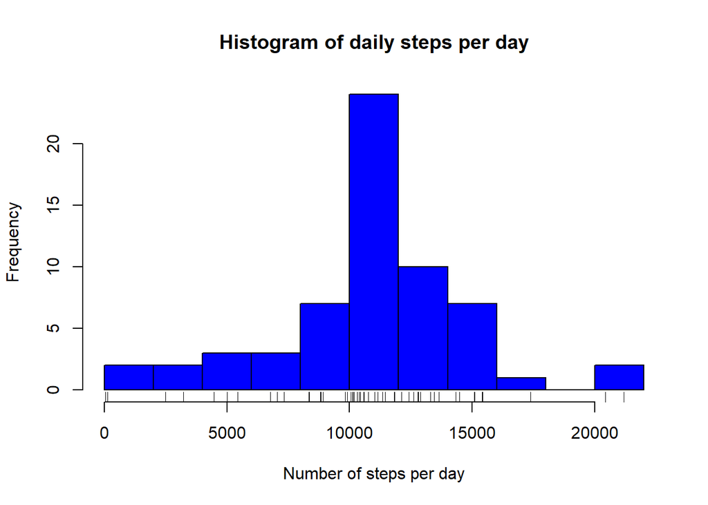

```r
plotdatacomplete <- completedata %>% group_by(date) %>% summarise(steps = sum(steps))
hist(plotdatacomplete$steps, breaks = 15, xlab = "Number of steps per day", main = "Histogram of daily steps per day", col = "blue")
rug(plotdatacomplete$steps)
```

```r
steps_summary_completedata <- completedata %>% group_by(date) %>% summarise(steps = sum (steps))
meantotal <- as.integer(mean(steps_summary_completedata$steps,na.rm = T))
mediantotal <- as.integer(median(steps_summary_completedata$steps,na.rm = T))
```

The mean of steps per day from the dataset without missing values is **10766** and the median from the same dataset is **10766**.

```r
diffmean <- meantotal - meansteps
diffmedian <- mediantotal - mediansteps
```

## Difference in activity patterns between weekdays and weekends

```r
completedata$day <- weekdays(completedata$date)
completedata$weekday <- ifelse(completedata$day == "Saturday" | completedata$day == "Sunday", "Weekend", "Weekday")
completedata$weekday <- as.factor(completedata$weekday)
completedata <- completedata %>% group_by(weekday,interval) %>% summarise(steps = mean(steps, na.rm=T))
```

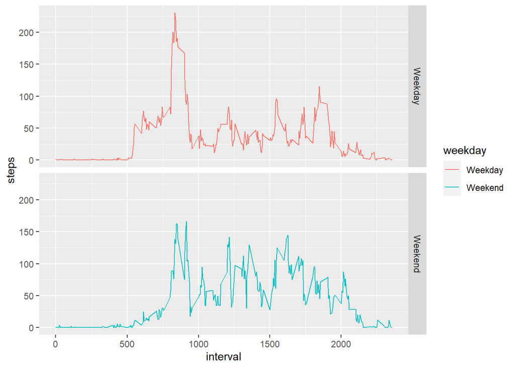

```r
qplot(x = interval, y = steps, data = completedata, facets = weekday~.,geom = "path",color = weekday)
```